# Applied Statistics

Please answer the following questions with all relevant assumptions, explanations and details. Q1. Please refer the table below to answer below questions:

```python
import pandas as pd
prodA_prob = pd.read_csv("ProdASalesProb.csv")
prodA_prob
```

|  | Planned to Purchase Product A | Actually placed order For Product A - Yes | ctually placed order For Product A - No | Total |
| --- | --- | --- | --- | --- |
| 0 | Yes | 400 | 100 | 500 |
| 1 | No | 200 | 1300 | 1500 |
| 2 | Total | 600 | 1400 | 2000 |

Q1.A Refer above table and find the joint probability of the people who planned to purchase and actually placed an order.

```python
# Planned to Puchase and actually purchased = 400
# Total = 2000
prob_planned_and_actual = 400 / 2000
print("prob(People who planned to purchase and actually placed the order) = ",prob_planned_and_actual)
```

```
prob(People who planned to purchase and actually placed the order) =  0.2
```

Q1.B Refer to the above table and find the joint probability of the people who planned to purchase and actually placed an order, given that people planned to purchase.

```python
#prob(People who planned to purchase) P(B) = 500 / 2000
#prob(People who planned to purchase and actually placed the order ) P( A and B ) = 400/2000
#prob ( acually placed the order | planned to purchase )  P(C) i.e. ( A | B) = P(A and B) / P(B)
p_c = (400/2000) / (500/2000)
print("prob ( Acually placed the order | planned to purchase ) = ",p_c)
```

```
prob ( Acually placed the order | planned to purchase ) =  0.8
```

Q2. An electrical manufacturing company conducts quality checks at specified periods on the products it manufactures. Historically, the failure rate for the manufactured item is 5%. Suppose a random sample of 10 manufactured items is selected. Answer the following questions.

A. Probability that none of the items are defective?

B. Probability that exactly one of the items is defective?

C. Probability that two or fewer of the items are defective?

D. Probability that three or more of the items are defective ?

```python
import numpy             as np
import pandas            as pd
import scipy.stats       as stats
```

```python
#samples 10 less than 30 use binomial distribution
n= 10
#prob of defect 0.05%
p=0.05
k = np.arange(0,11) # 10 items selected
k
```

```
array([ 0,  1,  2,  3,  4,  5,  6,  7,  8,  9, 10])
```

```python
#bionimial distribution
bin_dist = stats.binom.pmf(k,n,p)
bin_dist
```

```
array([5.98736939e-01, 3.15124705e-01, 7.46347985e-02, 1.04750594e-02,
       9.64808106e-04, 6.09352488e-05, 2.67259863e-06, 8.03789063e-08,
       1.58642578e-09, 1.85546875e-11, 9.76562500e-14])
```

```python
# A. Probability that none of the items are defective?
print("Q2 A. Probability that none of the items are defective? = %1.4f "%bin_dist[0])
```

```
Q2 A. Probability that none of the items are defective? = 0.5987
```

```python
# B. Probability that exactly one of the items is defective?
print("Q2 B. Probability that exactly one of the items is defective? = %1.4f "%bin_dist[1])
```

```
Q2 B. Probability that exactly one of the items is defective? = 0.3151
```

```python
# C. Probability that two or fewer of the items are defective?
# probablity no item is defective + prob one item is defective + prob two items are defective
print("Q2 C. Probability that two or fewer of the items are defective? = %1.4f "%(bin_dist[0] + bin_dist[1] + bin_dist[2]))
```

```
Q2 C. Probability that two or fewer of the items are defective? = 0.9885
```

```python
#D. Probability that three or more of the items are defective ?
# 1 - ( probablity no item is defective + prob one item is defective + prob two items are defective )
p_d = 1 - (bin_dist[0] + bin_dist[1] + bin_dist[2])
print("Q2 D. Probability that three or more of the items are defective ? = %1.4f" %p_d )
```

```
Q2 D. Probability that three or more of the items are defective ? = 0.0115
```

Q3. A car salesman sells on an average 3 cars per week.

A. What is Probability that in a given week he will sell some cars.

B. What is Probability that in a given week he will sell 2 or more but less than 5 cars.

C. Plot the poisson distribution function for cumulative probability of cars sold per-week vs number of cars sold per week.

```python
sales_avg = 3
#take a large number for for atleast 5 to 6 averages away
n = np.arange(0,16)
cum_poisson = stats.poisson.cdf(n,sales_avg)
cum_poisson
```

```
array([0.04978707, 0.19914827, 0.42319008, 0.64723189, 0.81526324,
       0.91608206, 0.96649146, 0.9880955 , 0.99619701, 0.99889751,
       0.99970766, 0.99992861, 0.99998385, 0.9999966 , 0.99999933,
       0.99999988])
```

```python
#Q3 A Pobability that salesman will sell some cars per week
# 1 - Prob( salesman will sell ZERO cars in the week)
p_some_cars  =  1- cum_poisson[0]
print("Pobability that saleman will sell some cars per week = %1.4f"%p_some_cars)
```

```
Pobability that saleman will sell some cars per week = 0.9502
```

```python
#Q3 B. What is Probability that in a given week he will sell 2 or more but less than 5 cars.
P1 = cum_poisson[4] #cum probaility of selling 0 or 1 or 2 or 3 or 4 cars
print(P1)
P2 = cum_poisson[1] #cum probability of selling 0 or 1 car
print(P2)
P = P1 - P2 # Prob. that the salesman will sell between 2 and 5 cars
print('Probability that in a given week salesman will sell 2 or more but less than 5 cars. %1.4f' % P)
```

```
0.8152632445237722
0.1991482734714558
Probability that in a given week salesman will sell 2 or more but less than 5 cars. 0.6161
```

[figure not shown]

```python
#Q3 C. Plot the poisson distribution function for cumulative probability of cars sold per-week vs number of cars sold per week.
import matplotlib.pyplot as plt
poisson = stats.poisson.pmf(n,sales_avg)
plt.plot(n, poisson, 'o-')
plt.title('Poisson Disribution')
plt.ylabel('Cumulative Prob of Cars sold/week')
plt.xlabel('Number of Cars sold /week')
plt.show()
```

Q4. Accuracy in understanding orders for a speech based bot at a restaurant is important for the Company X which has designed, marketed and launched the product for a contactless delivery due to the COVID-19 pandemic. Recognition accuracy that measures the percentage of orders that are taken correctly is 86.8%. Suppose that you place an order with the bot and two friends of yours independently place orders with the same bot. Answer the following questions.

A. What is the probability that all three orders will be recognised correctly?

B. What is the probability that none of the three orders will be recognised correctly?

C. What is the probability that at least two of the three orders will be recognised correctly?

```python
n= 3
#prob of defect 0.05%
p=0.868
k = np.arange(0,4)
bin_dist_order = stats.binom.pmf(k,n,p)
bin_dist_order
```

```
array([0.00229997, 0.0453721 , 0.2983559 , 0.65397203])
```

```python
print("Q4 A. Probability that all three orders will be recognised correctly =%1.4f"%bin_dist_order[3])
```

```
Q4 A. Probability that all three orders will be recognised correctly =0.6540
```

```python
print("Q4 B. Probability that none of the three orders will be recognised correctly? =%1.4f"%bin_dist_order[0])
```

```
Q4 B. Probability that none of the three orders will be recognised correctly? =0.0023
```

```python
print("Q4 C. probability that at least two of the three orders will be recognised correctly?? =%1.4f"%(bin_dist_order[2] + bin_dist_order[3]))
```

```
Q4 C. probability that at least two of the three orders will be recognised correctly?? =0.9523
```

Q5. Explain 1 real life industry scenario (other than the ones mentioned above) where you can use the concepts learnt in this module of Applied statistics to get a data driven business solution

### Solution Q5 :

Salaries on private organisations have a complex structure. There are three major parameters to determine the salaries

1. Role and Tile including years of service
2. Performance Rating
3. For a given Role, what is the range in which the market is paying For e.g. software engineer salary range may be from 15 LPA to 20 LPA in 2021. During year-end statistics helps us to understand that a software engineer within our organisation is How close to the organisation median How close to the industry median What is the salary distribution curve for incumbent employees? What is the interquartile difference between new employees compared to the incumbents in the organisation for a long time? Motivation level if the mean is not corrected As a manager, statistics will help me to use data for decision making and taking correct decisions.

# Q6

Domain: Sports ● Context: Company X manages the men's top professional basketball division of the American league system. The dataset contains information on all the teams that have participated in all the past tournaments. It has data about how many baskets each team scored, conceded, how many times they came within the first 2 positions, how many tournaments they have qualified, their best position in the past, etc. ● Data Description: Basketball.csv - The data set contains information on all the teams so far participated in all the past tournaments. ● Data Dictionary:

1. Team: Team’s name
2. Tournament: Number of played tournaments.
3. Score: Team’s score so far.
4. PlayedGames: Games played by the team so far.
5. WonGames: Games won by the team so far.
6. DrawnGames: Games drawn by the team so far.
7. LostGames: Games lost by the team so far.
8. BasketScored: Basket scored by the team so far.
9. BasketGiven: Basket scored against the team so far.
10. TournamentChampion: How many times the team was a champion of the tournaments so far.
11. Runner-up: How many times the team was a runners-up of the tournaments so far.
12. TeamLaunch: Year the team was launched on professional basketball.
13. HighestPositionHeld: Highest position held by the team amongst all the tournaments played.

● Project Objective: Company’s management wants to invest on proposals on managing some of the best teams in the league. The analytics department has been assigned with a task of creating a report on the performance shown by the teams. Some of the older teams are already in contract with competitors. Hence Company X wants to understand which teams they can approach which will be a deal win for them.

● Steps and Tasks:

1. Read the data set, clean the data and prepare final dataset to be used for analysis. [10 Marks]
2. Perform detailed statistical analysis and EDA using univariate, bi-variate and multivariate EDA techniques to get data driven insights on recommending which teams they can approach which will be a deal win for them. Also as a data and statistics expert you have to develop a detailed performance report using this data. [10 Marks] Hint: Use statistical techniques and visualisation techniques to come up with useful metrics and reporting. Find out the best performing team, oldest team, team with highest goals, team with lowest performance etc. and many more. These are just random examples. Please use your best analytical approach to build this report. You can mix match columns to create new ones which can be used for better analysis. Create your own features if required. Be highly experimental and analytical here to find hidden patterns. Use graphical interactive libraries to enable you to publish interactive plots in python.
3. Please include any improvements or suggestions to the association management on quality, quantity, variety, velocity, veracity etc. on the data points collected by the association to perform a better data analysis in future. At-least 1 suggestion for each point. [10 Marks]

```python
# Thought process : Company will make money where
# Team plays maximum matches may even come in finals
# Team win maximum matches
# New team with highest wins - rising starts most talked about
# More nail biting matches more entertainment value

import pandas as pd
basketball_dst = pd.read_csv("basketball.csv")

print(f" Shape of the dataframe = {basketball_dst.shape}")
totalrows=basketball_dst.shape[0]
print(f" Total number of rows in the dataset =  {totalrows}")
```

```
 Shape of the dataframe = (61, 13)
 Total number of rows in the dataset =  61
```

```python
# Checking Null colunms
basketball_nullcols = basketball_dst.isnull().sum()
basketball_nullcols
```

```
Team                   0
Tournament             0
Score                  0
PlayedGames            0
WonGames               0
DrawnGames             0
LostGames              0
BasketScored           0
BasketGiven            0
TournamentChampion     0
Runner-up              0
TeamLaunch             0
HighestPositionHeld    0
dtype: int64
```

# No null values are found

```python
#checking cloumns data types
basketball_dst.dtypes
```

```
Team                   object
Tournament              int64
Score                  object
PlayedGames            object
WonGames               object
DrawnGames             object
LostGames              object
BasketScored           object
BasketGiven            object
TournamentChampion     object
Runner-up              object
TeamLaunch             object
HighestPositionHeld     int64
dtype: object
```

```python
basketball_dst
```

|  | Team | Tournament | Score | PlayedGames | WonGames | DrawnGames | LostGames | BasketScored | BasketGiven | TournamentChampion | Runner-up | TeamLaunch | HighestPositionHeld |
| --- | --- | --- | --- | --- | --- | --- | --- | --- | --- | --- | --- | --- | --- |
| 0 | Team 1 | 86 | 4385 | 2762 | 1647 | 552 | 563 | 5947 | 3140 | 33 | 23 | 1929 | 1 |
| 1 | Team 2 | 86 | 4262 | 2762 | 1581 | 573 | 608 | 5900 | 3114 | 25 | 25 | 1929 | 1 |
| 2 | Team 3 | 80 | 3442 | 2614 | 1241 | 598 | 775 | 4534 | 3309 | 10 | 8 | 1929 | 1 |
| 3 | Team 4 | 82 | 3386 | 2664 | 1187 | 616 | 861 | 4398 | 3469 | 6 | 6 | 1931to32 | 1 |
| 4 | Team 5 | 86 | 3368 | 2762 | 1209 | 633 | 920 | 4631 | 3700 | 8 | 7 | 1929 | 1 |
| ... | ... | ... | ... | ... | ... | ... | ... | ... | ... | ... | ... | ... | ... |
| 56 | Team 57 | 1 | 34 | 38 | 8 | 10 | 20 | 38 | 66 | - | - | 2009-10 | 20 |
| 57 | Team 58 | 1 | 22 | 30 | 7 | 8 | 15 | 37 | 57 | - | - | 1956-57 | 16 |
| 58 | Team 59 | 1 | 19 | 30 | 7 | 5 | 18 | 51 | 85 | - | - | 1951~52 | 16 |
| 59 | Team 60 | 1 | 14 | 30 | 5 | 4 | 21 | 34 | 65 | - | - | 1955-56 | 15 |
| 60 | Team 61 | 1 | - | - | - | - | - | - | - | - | - | 2017~18 | 9 |

61 rows × 13 columns

```python
#there are some characters in the data primarily '-', '_', '~' causing some of the columns not to be treated as
#numbers. Cleanting that up.
#data clean-up for convenience assume where data in unavailable to Zero
basketball_dst = basketball_dst.replace('-',0)
# TeamLaunch column has lot of data standardisation issues. replace the matching strings to standardise data
basketball_dst = basketball_dst.replace(to_replace ='to', value = '-', regex = True)
basketball_dst = basketball_dst.replace(to_replace ='_', value = '-', regex = True)
basketball_dst = basketball_dst.replace(to_replace ='~', value = '-', regex = True)
```

### View the data after clean-up

```python
basketball_dst
```

|  | Team | Tournament | Score | PlayedGames | WonGames | DrawnGames | LostGames | BasketScored | BasketGiven | TournamentChampion | Runner-up | TeamLaunch | HighestPositionHeld |
| --- | --- | --- | --- | --- | --- | --- | --- | --- | --- | --- | --- | --- | --- |
| 0 | Team 1 | 86 | 4385 | 2762 | 1647 | 552 | 563 | 5947 | 3140 | 33 | 23 | 1929 | 1 |
| 1 | Team 2 | 86 | 4262 | 2762 | 1581 | 573 | 608 | 5900 | 3114 | 25 | 25 | 1929 | 1 |
| 2 | Team 3 | 80 | 3442 | 2614 | 1241 | 598 | 775 | 4534 | 3309 | 10 | 8 | 1929 | 1 |
| 3 | Team 4 | 82 | 3386 | 2664 | 1187 | 616 | 861 | 4398 | 3469 | 6 | 6 | 1931-32 | 1 |
| 4 | Team 5 | 86 | 3368 | 2762 | 1209 | 633 | 920 | 4631 | 3700 | 8 | 7 | 1929 | 1 |
| ... | ... | ... | ... | ... | ... | ... | ... | ... | ... | ... | ... | ... | ... |
| 56 | Team 57 | 1 | 34 | 38 | 8 | 10 | 20 | 38 | 66 | 0 | 0 | 2009-10 | 20 |
| 57 | Team 58 | 1 | 22 | 30 | 7 | 8 | 15 | 37 | 57 | 0 | 0 | 1956-57 | 16 |
| 58 | Team 59 | 1 | 19 | 30 | 7 | 5 | 18 | 51 | 85 | 0 | 0 | 1951-52 | 16 |
| 59 | Team 60 | 1 | 14 | 30 | 5 | 4 | 21 | 34 | 65 | 0 | 0 | 1955-56 | 15 |
| 60 | Team 61 | 1 | 0 | 0 | 0 | 0 | 0 | 0 | 0 | 0 | 0 | 2017-18 | 9 |

61 rows × 13 columns

```python
basketball_dst.info()
```

```
<class 'pandas.core.frame.DataFrame'>
RangeIndex: 61 entries, 0 to 60
Data columns (total 13 columns):
 #   Column               Non-Null Count  Dtype
---  ------               --------------  -----
 0   Team                 61 non-null     object
 1   Tournament           61 non-null     int64
 2   Score                61 non-null     object
 3   PlayedGames          61 non-null     object
 4   WonGames             61 non-null     object
 5   DrawnGames           61 non-null     object
 6   LostGames            61 non-null     object
 7   BasketScored         61 non-null     object
 8   BasketGiven          61 non-null     object
 9   TournamentChampion   61 non-null     object
 10  Runner-up            61 non-null     object
 11  TeamLaunch           61 non-null     object
 12  HighestPositionHeld  61 non-null     int64
dtypes: int64(2), object(11)
memory usage: 6.3+ KB
```

```python
#there are some numerical data types not being treated as numerical becasue of "-" in the data earlier
# typecasing them to be seen an numberical data

# To convert TeamLaunch to a year take first four numbers as year
basketball_dst['TeamLaunch'] = basketball_dst['TeamLaunch'].str[:4]

basketball_dst = basketball_dst.astype({
    'Tournament': 'int64',
    'Score': 'int64',
    'PlayedGames': 'int64',
    'WonGames': 'int64',
    'DrawnGames': 'int64',
    'LostGames': 'int64',
    'BasketScored': 'int64',
    'BasketGiven': 'int64',
    'TournamentChampion': 'int64',
    'Runner-up': 'int64',
    'TeamLaunch': 'int64'
    })
```

```python
#validate if columns are converted to int
basketball_dst.info()
```

```
<class 'pandas.core.frame.DataFrame'>
RangeIndex: 61 entries, 0 to 60
Data columns (total 13 columns):
 #   Column               Non-Null Count  Dtype
---  ------               --------------  -----
 0   Team                 61 non-null     object
 1   Tournament           61 non-null     int64
 2   Score                61 non-null     int64
 3   PlayedGames          61 non-null     int64
 4   WonGames             61 non-null     int64
 5   DrawnGames           61 non-null     int64
 6   LostGames            61 non-null     int64
 7   BasketScored         61 non-null     int64
 8   BasketGiven          61 non-null     int64
 9   TournamentChampion   61 non-null     int64
 10  Runner-up            61 non-null     int64
 11  TeamLaunch           61 non-null     int64
 12  HighestPositionHeld  61 non-null     int64
dtypes: int64(12), object(1)
memory usage: 6.3+ KB
```

### Analysis: No null data 61 enteries and all 61 entries have data. At many places zero but that is for convenience

```python
#see the data
basketball_dst.head(10)
```

|  | Team | Tournament | Score | PlayedGames | WonGames | DrawnGames | LostGames | BasketScored | BasketGiven | TournamentChampion | Runner-up | TeamLaunch | HighestPositionHeld |
| --- | --- | --- | --- | --- | --- | --- | --- | --- | --- | --- | --- | --- | --- |
| 0 | Team 1 | 86 | 4385 | 2762 | 1647 | 552 | 563 | 5947 | 3140 | 33 | 23 | 1929 | 1 |
| 1 | Team 2 | 86 | 4262 | 2762 | 1581 | 573 | 608 | 5900 | 3114 | 25 | 25 | 1929 | 1 |
| 2 | Team 3 | 80 | 3442 | 2614 | 1241 | 598 | 775 | 4534 | 3309 | 10 | 8 | 1929 | 1 |
| 3 | Team 4 | 82 | 3386 | 2664 | 1187 | 616 | 861 | 4398 | 3469 | 6 | 6 | 1931 | 1 |
| 4 | Team 5 | 86 | 3368 | 2762 | 1209 | 633 | 920 | 4631 | 3700 | 8 | 7 | 1929 | 1 |
| 5 | Team 6 | 73 | 2819 | 2408 | 990 | 531 | 887 | 3680 | 3373 | 1 | 4 | 1934 | 1 |
| 6 | Team 7 | 82 | 2792 | 2626 | 948 | 608 | 1070 | 3609 | 3889 | 0 | 0 | 1929 | 3 |
| 7 | Team 8 | 70 | 2573 | 2302 | 864 | 577 | 861 | 3228 | 3230 | 2 | 3 | 1929 | 1 |
| 8 | Team 9 | 58 | 2109 | 1986 | 698 | 522 | 766 | 2683 | 2847 | 0 | 1 | 1939 | 2 |
| 9 | Team 10 | 51 | 1884 | 1728 | 606 | 440 | 682 | 2159 | 2492 | 1 | 0 | 1932 | 1 |

```python
# get initital statistics of data
basketball_dst.describe(include = 'all').transpose()
```

|  | count | unique | top | freq | mean | std | min | 25% | 50% | 75% | max |
| --- | --- | --- | --- | --- | --- | --- | --- | --- | --- | --- | --- |
| Team | 61 | 61 | Team 60 | 1 | NaN | NaN | NaN | NaN | NaN | NaN | NaN |
| Tournament | 61.0 | NaN | NaN | NaN | 24.0 | 26.827225 | 1.0 | 4.0 | 12.0 | 38.0 | 86.0 |
| Score | 61.0 | NaN | NaN | NaN | 901.42623 | 1134.899121 | 0.0 | 96.0 | 375.0 | 1351.0 | 4385.0 |
| PlayedGames | 61.0 | NaN | NaN | NaN | 796.819672 | 876.282765 | 0.0 | 114.0 | 423.0 | 1318.0 | 2762.0 |
| WonGames | 61.0 | NaN | NaN | NaN | 303.967213 | 406.99103 | 0.0 | 34.0 | 123.0 | 426.0 | 1647.0 |
| DrawnGames | 61.0 | NaN | NaN | NaN | 188.934426 | 201.799477 | 0.0 | 24.0 | 95.0 | 330.0 | 633.0 |
| LostGames | 61.0 | NaN | NaN | NaN | 303.754098 | 294.708594 | 0.0 | 62.0 | 197.0 | 563.0 | 1070.0 |
| BasketScored | 61.0 | NaN | NaN | NaN | 1140.344262 | 1506.740211 | 0.0 | 153.0 | 430.0 | 1642.0 | 5947.0 |
| BasketGiven | 61.0 | NaN | NaN | NaN | 1140.229508 | 1163.710766 | 0.0 | 221.0 | 632.0 | 1951.0 | 3889.0 |
| TournamentChampion | 61.0 | NaN | NaN | NaN | 1.42623 | 5.472535 | 0.0 | 0.0 | 0.0 | 0.0 | 33.0 |
| Runner-up | 61.0 | NaN | NaN | NaN | 1.409836 | 4.540107 | 0.0 | 0.0 | 0.0 | 0.0 | 25.0 |
| TeamLaunch | 61.0 | NaN | NaN | NaN | 1958.918033 | 27.484114 | 1929.0 | 1935.0 | 1951.0 | 1978.0 | 2017.0 |
| HighestPositionHeld | 61.0 | NaN | NaN | NaN | 7.081967 | 5.276663 | 1.0 | 3.0 | 6.0 | 10.0 | 20.0 |

### Analysis : Not much pattern appearing from raw data. Most cases mean and median and far apart and std deviation quiet large

# EDA

## Univariate Analysis

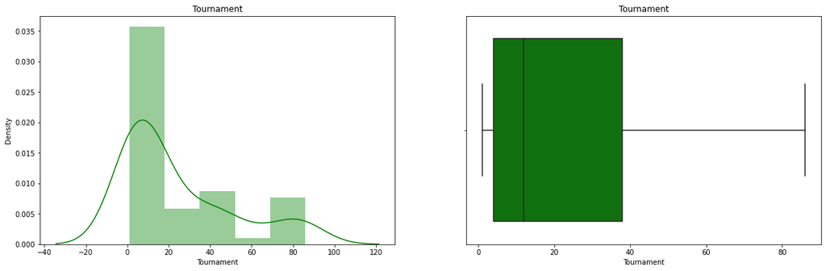

```python
import pandas as pd
import numpy as np
import matplotlib.pyplot as plt
import seaborn as sns
#
# Ignore warnings
import warnings
warnings.filterwarnings("ignore")
#
# To enable plotting graphs in Jupyter notebook
%matplotlib inline

#### Tournament
plt.figure(figsize=(20,6))
plt.subplot(1, 2, 1)
plt.title('Tournament')
sns.distplot(basketball_dst['Tournament'],color='green');

plt.subplot(1, 2, 2)
plt.title('Tournament')
sns.boxplot(basketball_dst['Tournament'],orient='vertical',color='green');
```

### Most of the teams have played less than 20 matches. there is a long tail i.e. teams that have played around 8+ matches.

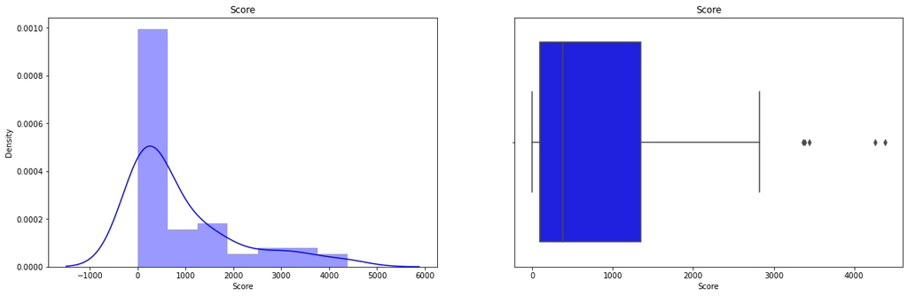

```python
#### Score
plt.figure(figsize=(20,6))
plt.subplot(1, 2, 1)
plt.title('Score')
sns.distplot(basketball_dst['Score'],color='blue');

plt.subplot(1, 2, 2)
plt.title('Score')
sns.boxplot(basketball_dst['Score'],orient='vertical',color='blue');
```

### Analysis there are 5 teams that are ourliers i.e. team1 to team 5. Even out of them team one and two are exceptional outliers

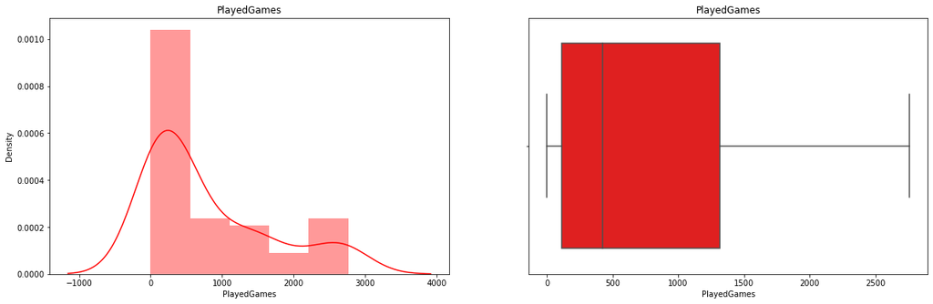

```python
#### PlayedGames
plt.figure(figsize=(20,6))
plt.subplot(1, 2, 1)
plt.title('PlayedGames')
sns.distplot(basketball_dst['PlayedGames'],color='red');

plt.subplot(1, 2, 2)
plt.title('PlayedGames')
sns.boxplot(basketball_dst['PlayedGames'],orient='vertical',color='red');
```

### 50% of th team have played less than 500 matches. There are set of teams that have played ~2500 + matches. there is a second localised peak for old teams that have played more around 2500+ matches.

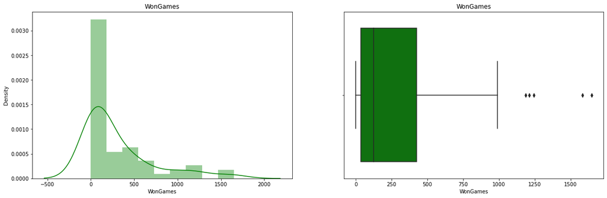

```python
#### WonGames
plt.figure(figsize=(20,6))
plt.subplot(1, 2, 1)
plt.title('WonGames')
sns.distplot(basketball_dst['WonGames'],color='green');

plt.subplot(1, 2, 2)
plt.title('WonGames')
sns.boxplot(basketball_dst['WonGames'],orient='vertical',color='green');
```

### Team 1 to Team 5 are outliers in terms of matches won. Team 1 and Team 2 are exceptional.

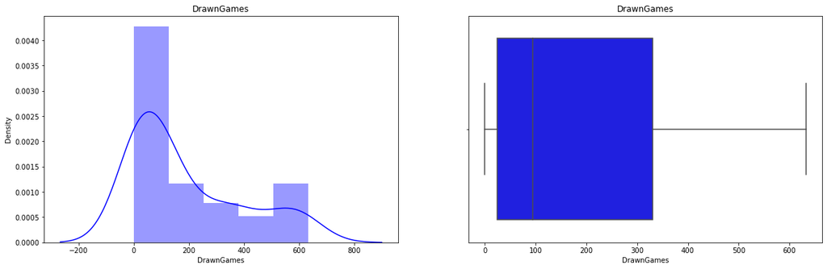

```python
#### DrawnGames
plt.figure(figsize=(20,6))
plt.subplot(1, 2, 1)
plt.title('DrawnGames')
sns.distplot(basketball_dst['DrawnGames'],color='blue');

plt.subplot(1, 2, 2)
plt.title('DrawnGames')
sns.boxplot(basketball_dst['DrawnGames'],orient='vertical',color='blue');
```

### There are some team with high number of matches drawn. Pushing the whiskers to ~600. This could be a sepeate hypothesis testing if those Teams coupld have won the matches. But sufficent data is no available to do that anaysis. Hence will not use this column in our analysis.

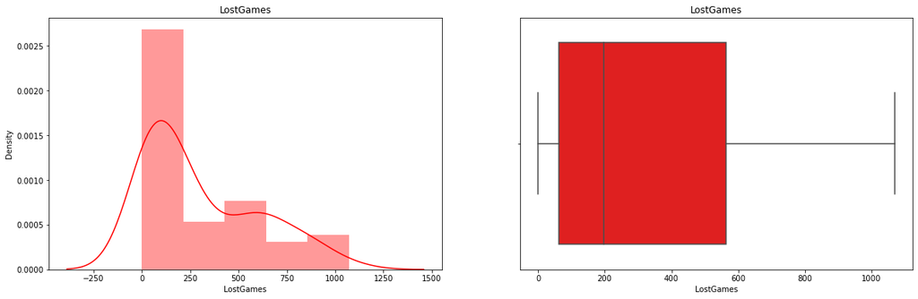

```python
#### LostGames
plt.figure(figsize=(20,6))
plt.subplot(1, 2, 1)
plt.title('LostGames')
sns.distplot(basketball_dst['LostGames'],color='red');

plt.subplot(1, 2, 2)
plt.title('LostGames')
sns.boxplot(basketball_dst['LostGames'],orient='vertical',color='red');
```

### Not much to say but the ratio of win to losses will be significant to analyse

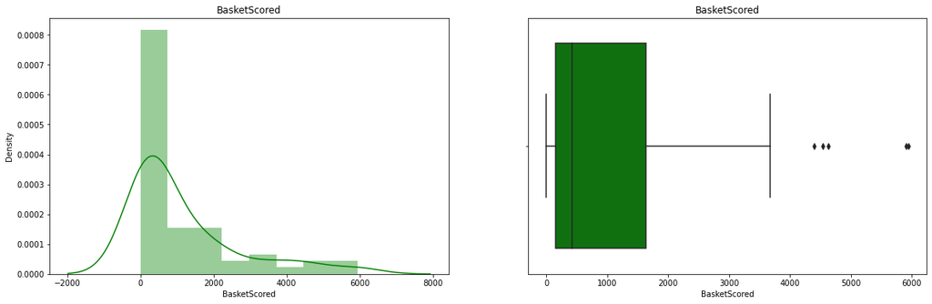

```python
#### BasketScored
plt.figure(figsize=(20,6))
plt.subplot(1, 2, 1)
plt.title('BasketScored')
sns.distplot(basketball_dst['BasketScored'],color='green');

plt.subplot(1, 2, 2)
plt.title('BasketScored')
sns.boxplot(basketball_dst['BasketScored'],orient='vertical',color='green');
```

### The graph is corretated to won games graph. Will see the colleration in heat maps when deciding distinct columns to analyse. Shows same 5 outliers

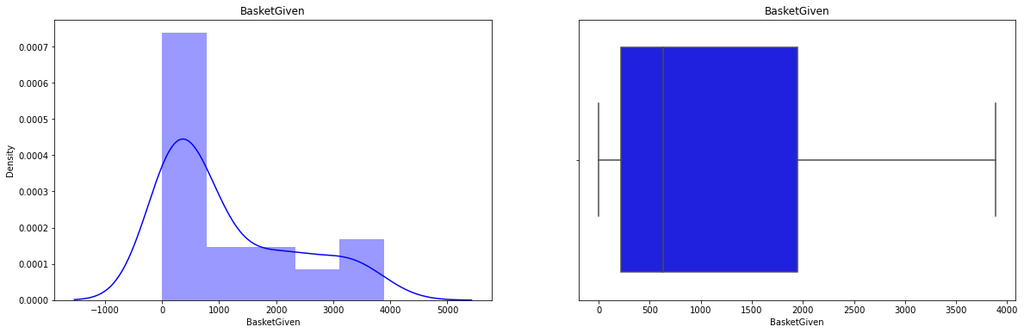

```python
#### BasketGiven
plt.figure(figsize=(20,6))
plt.subplot(1, 2, 1)
plt.title('BasketGiven')
sns.distplot(basketball_dst['BasketGiven'],color='blue');

plt.subplot(1, 2, 2)
plt.title('BasketGiven')
sns.boxplot(basketball_dst['BasketGiven'],orient='vertical',color='blue');
```

### Graph highy correated to LostGames

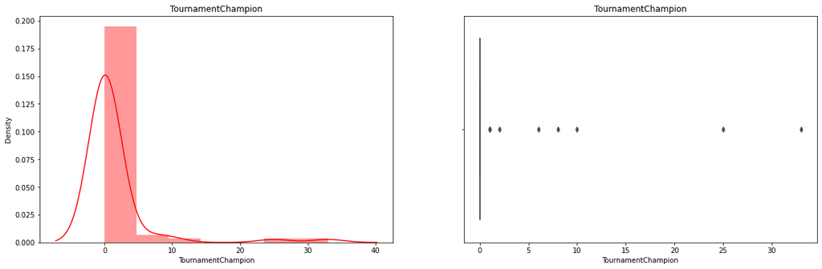

```python
#### TournamentChampion
plt.figure(figsize=(20,6))
plt.subplot(1, 2, 1)
plt.title('TournamentChampion')
sns.distplot(basketball_dst['TournamentChampion'],color='red');

plt.subplot(1, 2, 2)
plt.title('TournamentChampion')
sns.boxplot(basketball_dst['TournamentChampion'],orient='vertical',color='red');
```

### Out of a all the 60 teams very view have won the tournament. Looking data only 9 teams ever won. Two teams team-1 and team-2 are outliers in terms of winning the matches.

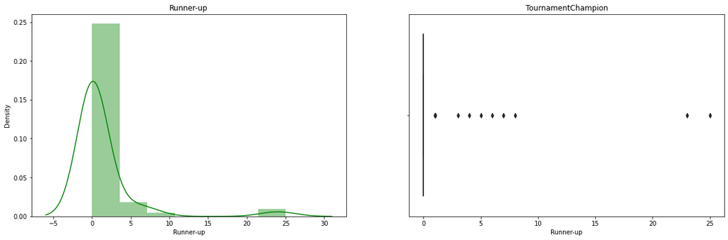

```python
#### Runner-up
plt.figure(figsize=(20,6))
plt.subplot(1, 2, 1)
plt.title('Runner-up')
sns.distplot(basketball_dst['Runner-up'],color='green');

plt.subplot(1, 2, 2)
plt.title('TournamentChampion')
sns.boxplot(basketball_dst['Runner-up'],orient='vertical',color='green');
```

### Out of a all the 60 teams very few teams landed in tournament as runnerup. Looking data only 13 teams ever won. We will later see if there is team that has potential but struggling. But good to see there are young disruptors that reach to runner-up positions like team 21.

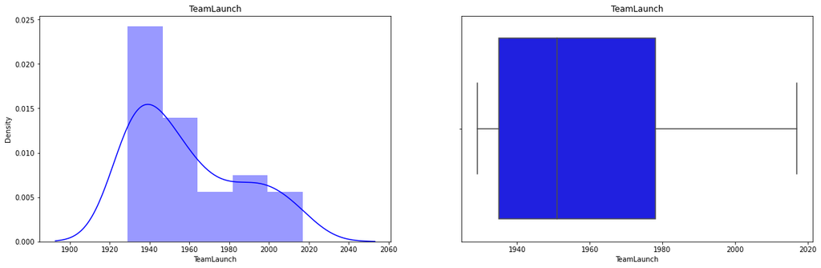

```python
#### TeamLaunch
plt.figure(figsize=(20,6))
plt.subplot(1, 2, 1)
plt.title('TeamLaunch')
sns.distplot(basketball_dst['TeamLaunch'],color='blue');

plt.subplot(1, 2, 2)
plt.title('TeamLaunch')
sns.boxplot(basketball_dst['TeamLaunch'],orient='vertical',color='blue');
```

### Good to see new team lauches between 1980 and 2000. There may be teams that have good vintange and potential there

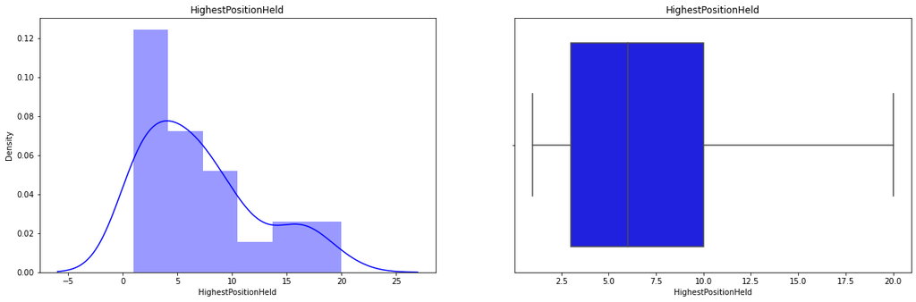

```python
#### HighestPositionHeld
plt.figure(figsize=(20,6))
plt.subplot(1, 2, 1)
plt.title('HighestPositionHeld')
sns.distplot(basketball_dst['HighestPositionHeld'],color='blue');

plt.subplot(1, 2, 2)
plt.title('HighestPositionHeld')
sns.boxplot(basketball_dst['HighestPositionHeld'],orient='vertical',color='blue');
```

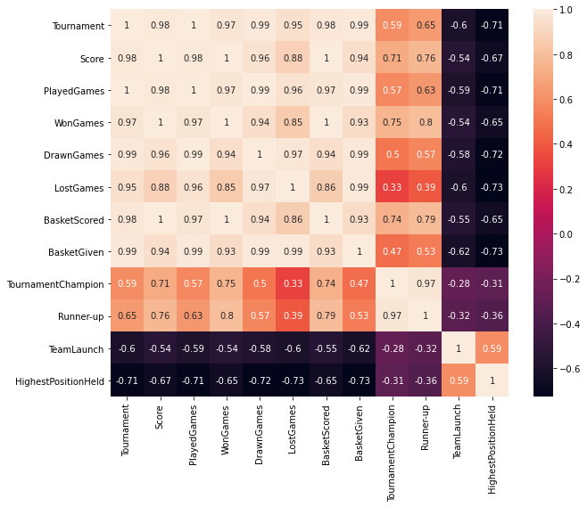

```python
# Using correration to identify independent variables to analyse
plt.figure(figsize=(10,8))
sns.heatmap(basketball_dst.corr(),annot=True)
```

### Looking at the amount of correlation 5 variables will be good to analyse

1. Higest Position Held
2. Team Launch ( Age of team )
3. Number of times tournament champion
4. Runner-up
5. Won games / Total number of games played

However we will not these variables as is some effort required to calculate

1. Winning percentage of team
2. Age of Team
3. Tournament win pecertage
4. Percentage that team teached Finals ( i.e to include cases where they were Runner-up)

```python
# Creating New features : win percentage
# teams with highest win percentage will be of particular interest to us
basketball_dst['WinPct']=basketball_dst['WonGames']*100/basketball_dst['PlayedGames']

# Creating New features : TeamAge
# Young teams with high wininng percentages not yet spotted is on interest to us
from datetime import date
basketball_dst['TeamAge'] = date.today().year - basketball_dst['TeamLaunch']

# Creating a new feature : TournamentWinPct
# what is the percentage that if a team particiapte in tournament they become tournament champtions
# Creating new feature TournamentWinPct
basketball_dst['TournamentWinPct'] = basketball_dst['TournamentChampion']*100/basketball_dst['Tournament']

# Creating a new feature : RunnerUpPct
#Analysinsg the runner up percentage
# Since investors make money if team reaches finals
basketball_dst['RunnerUpPct'] = (basketball_dst['Runner-up'])*100/basketball_dst['Tournament']

# Along with HighestPositionHeld adding above comumns to recommendation df that we will analsyse
recommendation_df=basketball_dst.filter(['Team','TournamentWinPct','WinPct', 'TeamAge','RunnerUpPct', 'HighestPositionHeld'])
```

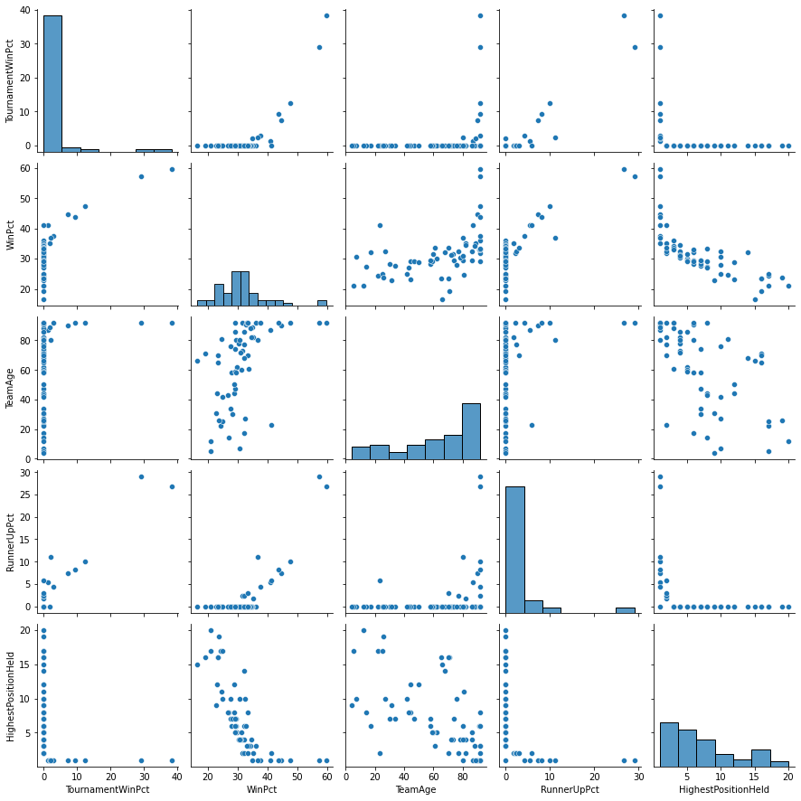

```python
## Creating pair plots to broadly understand the realationships
sns.pairplot(recommendation_df)
```

# Analysis

### 1. HighestPositionHeld vs TournamentWinPct : Graphs show mostly there are two team that reach the final and win. Some times other teams have reached Finals or have won but that is mostly one them fluke and not consistent.

### 2. HighestPositionHeld vs WinPct : Plot shows that there are 5 to 6 teams that have good winning record between 40% and 50% have come close to postion one or two. Two other teams are compelte outiers.

### 3. HighestPositionHeld vs TeamAge : There in only one young team that has come in Top 5 with age between 20 and 25. Looking at data its Team 21 with age 23 years.

### 4. Highest position held vs RunnerUpPct: Graphs show mostly there are two team that reach the final and win. Some times other teams have reached Finals and there are some disputors, mostly one time gig. Mostly noise but young teams that have reached high in tournament may we of some interest to us.

### 5. RunnerUpPct and TournamentWinPct : Team 1 and Team 2 are clear outlyers. There are some teams with higher runner up percentage we will analyse them later.

### 6. RunnerUpPct and WinPct : Team 1 and Team 2 are clear outlyers. There are some teams with good teams with both high Matches win percentage and that have been runner up. They can be of interest to management

### 7. RunnerUpPct and Age : There is a team that has reached runner up position and is quiet young compared to other teams. That can be a good team to observe.

### 8. TeamAge and TournamentWinPct: There has not been any exceptions here teams with almost age 80 and above have won.

### 9. Team Age and WinPct : There are some teams that are young and have high winning percentage. We need to identify those teams.

### 10. WinPct and TournamentWinPct : Team 1 and Team 2 are clear outlyers. There is a team that has high win percentage but never won the tournament, would need to be investigated

# 1. Analysing above deductions in details

```python
### Ordering teams with win percentage
import plotly.express as px
fig = px.histogram(recommendation_df, x="Team", y="WinPct", color="Team")
fig.show()
```

[interactive chart not shown]

## Analysis :

### We can Analyse Team 21 standing out.

# Analysing point 10 from pairplot : WinPct and TournamentWinPct

```python
import plotly.express as px
fig = px.scatter(recommendation_df, x="WinPct", y="TournamentWinPct", size="TeamAge", color="Team")
fig.show()
```

[interactive chart not shown]

## Analysis

### 1. Again Team 21 is yongest of the teams with high Winning Percentage.

### 2. There is another good team Team 44, only 7 years ols and have winning percentage in 30's

### 3. Team 6 also have a higher winning percentage but has been unfortunate. It can be a good pick where company can make a difference

# Analysing point 9 from pairplot: TeamAge and WinPct

```python
fig = px.scatter(recommendation_df, x="TeamAge", y="WinPct", size="TeamAge", color="Team")
fig.show()
```

[interactive chart not shown]

### 1. Again Team 21 is yongest of the teams with high Winning Percentage, its comparable to the winning percentage of old team > 80 year

### 2. Team 44 is also has high percentage for teams less than 10 years

### 3. Team 25 also has high percentage for teams less than 20 years

# Analysing point 8 from pairplot: TeamAge and TournamentWinPct

```python
fig = px.scatter(recommendation_df, x="TeamAge", y="TournamentWinPct", size="TeamAge", color="Team")
fig.show()
```

[interactive chart not shown]

## Analysis

### Not much to deduce here other that tournaments champions are mostly old team.

# Analysing point 7 from pairplot: RunnerUpPct and TeamAge

```python
fig = px.scatter(recommendation_df, x="TeamAge", y="RunnerUpPct", size="TeamAge", color="Team")
fig.show()
```

[interactive chart not shown]

## Analysis

### Team 21 is the youngest team that went to finals

### Team 11 has been quiet unfortunate in Finals. Went to Finals but lost. Can be a good team to manage

# Analysing point 6 from pairplot: RunnerUpPct and WinPct

```python
fig = px.scatter(recommendation_df, x="RunnerUpPct", y="WinPct", size="TeamAge", color="Team")
fig.show()
```

[interactive chart not shown]

## Analysis

### Team 21 is the youngest team that has been Runner-up

### Team 6 has a higer match winning potential but have backed less runner-up slots.

### Team 11 though has low winning pct but in good seasons they do reach runner up positions.

# Analysing point 5 from pairplot: RunnerUpPct and TournamentWinPct

```python
fig = px.scatter(recommendation_df, x="RunnerUpPct", y="TournamentWinPct", size="TeamAge", color="Team")
fig.show()
```

[interactive chart not shown]

## Analysis

### Team 11 has reached runner up position many times.

### Team 21 may not have won but is young team which has been runner up atleast once

# Analysing point 4 from pairplot: HighestPositionHeld vs RunnerUpPct

```python
fig = px.scatter(recommendation_df, x="HighestPositionHeld", y="RunnerUpPct", size="TeamAge", color="Team")
fig.show()
```

[interactive chart not shown]

## Analysis :

Not much to deduce except for team 21 which we already know

# Analysing point 3 from pairplot: HighestPositionHeld vs TeamAge

```python
fig = px.scatter(recommendation_df, x="HighestPositionHeld", y="TeamAge", size="TeamAge", color="Team")
fig.show()
```

[interactive chart not shown]

## Analysing visually

### 1. Team 21 most impressive wrt age and higest postion held.

### 2. Next Team 25 , Team 37 , Team 61, Team 44 who are young team that made to top 10. Yourng disruptoes

# Analysing point 2 from pairplot: HighestPositionHeld vs WinPct

```python
fig = px.scatter(recommendation_df, x="HighestPositionHeld", y="WinPct", size = "TeamAge", color="Team")
fig.show()
```

[interactive chart not shown]

## Analysis :

### Team 21 has higest win percentage for those who ever reacted till postion 2

### Team 7 has higest win percentage for those who ever reacted till postion 3

# Analysing point 1 from pairplot: HighestPositionHeld vs TournamentWinPct

```python
fig = px.scatter(recommendation_df, x="HighestPositionHeld", y="TournamentWinPct", size = "TeamAge", color="Team")
fig.show()
```

[interactive chart not shown]

## Analysis

### No further unique point to recommend

# Solution :

### Based on above analysis as an executive summary I would recommend Company to reach out top 10 teams in the order given below. Teams on the top may be most difficult to get as they are old teams and would have know contacts in market. Starting reverse order i.e. Team 21, Team 6, Team 10, Team 11, Team 8 etc will help in terms of success rates.

No. Team TournamentWinPct WinPct TeamAge RunnerUpPct HighestPositionHeld

0 Team 1 38.372093 59.630702 92 26.744186 1

1 Team 2 29.069767 57.241130 92 29.069767 1

2 Team 3 12.500000 47.475134 92 10.000000 1

4 Team 5 9.302326 43.772629 92 8.139535 1

5 Team 4 7.317073 44.557057 90 7.317073 1

6 Team 8 2.857143 37.532580 92 4.285714 1

7 Team 11 2.222222 36.797386 80 11.111111 1

8 Team 10 1.960784 35.069444 89 0.000000 1

9 Team 6 1.369863 41.112957 87 5.479452 1

10 Team 21 0.000000 41.176471 23 5.882353 2

### Team 44 gets special mention for being the young team going good and can be on watch list

```python
recommendation_df.filter(['Team','TournamentWinPct','WinPct','TeamAge', 'RunnerUpPct' , 'HighestPositionHeld']).sort_values(by=['TournamentWinPct','WinPct','TeamAge', 'RunnerUpPct' , 'HighestPositionHeld'],ascending=[False,False,True,False,True ]).head(15)
```

|  | Team | TournamentWinPct | WinPct | TeamAge | RunnerUpPct | HighestPositionHeld |
| --- | --- | --- | --- | --- | --- | --- |
| 0 | Team 1 | 38.372093 | 59.630702 | 92 | 26.744186 | 1 |
| 1 | Team 2 | 29.069767 | 57.241130 | 92 | 29.069767 | 1 |
| 2 | Team 3 | 12.500000 | 47.475134 | 92 | 10.000000 | 1 |
| 4 | Team 5 | 9.302326 | 43.772629 | 92 | 8.139535 | 1 |
| 3 | Team 4 | 7.317073 | 44.557057 | 90 | 7.317073 | 1 |
| 7 | Team 8 | 2.857143 | 37.532580 | 92 | 4.285714 | 1 |
| 10 | Team 11 | 2.222222 | 36.797386 | 80 | 11.111111 | 1 |
| 9 | Team 10 | 1.960784 | 35.069444 | 89 | 0.000000 | 1 |
| 5 | Team 6 | 1.369863 | 41.112957 | 87 | 5.479452 | 1 |
| 20 | Team 21 | 0.000000 | 41.176471 | 23 | 5.882353 | 2 |
| 6 | Team 7 | 0.000000 | 36.100533 | 92 | 0.000000 | 3 |
| 8 | Team 9 | 0.000000 | 35.146022 | 82 | 1.724138 | 2 |
| 11 | Team 12 | 0.000000 | 34.511190 | 82 | 0.000000 | 4 |
| 17 | Team 18 | 0.000000 | 34.228188 | 88 | 0.000000 | 3 |
| 18 | Team 19 | 0.000000 | 33.704453 | 61 | 0.000000 | 3 |

## Q5.3 Please include any improvements or suggestions to the association management on quality, quantity, variety, velocity, veracity etc. on the data points collected by the association to perform a better data analysis in future. At-least 1 suggestion for each point.

### Solution :

### Quality :

Quality of data could have been better e.g. some key data was missing w.r.t. new team i.e. team 61 that team rose to postion 9 very quickly but no data was available to help see merit in their performance. Data completeness was missing and hence replaced it with zeros for analysing the data.

### Quantity :

Volume of data was ok for this analysis. Considering that there are two outliers in the data set other teams data could be removed.

### I was thinking to drop Team1 and Team2 to do the analsysis because presence of Team1 and Team2 compeltely skews the performance and growth of other teams.

### Variety:

Variety of data could be increase e.g. key player in the team. Baskets scored by them etc. Since then we ould have better command on what's helping the team to win. Another key data missing was when was the last time higest position was scored. Since with that data lot of deductions would change. There is also no break-up of last 5 years scores, that would have helped significanly.

### Velocity:

Data is old. data from recent records are missing i.e. newer teams like team 61. Also after 2018 there has been no data i.e. if any new teams came. Also data recency split. Since the data is old the accuracy of data while making decisions today in 2021 is an issue.

### Veracity :

The source of data and publishing authority for data was not mentioned. Hence accuracy or truthfulness of data is not guaranteed. While publishing the data things like league details, from where the data was colelcted, when it was collected etc. should have been provided. Also considering that its obselete data using it to make suggestions in 2021 is incorrect.

# Q6

## Domain:

Startup ecosystem

## Context:

CONTEXT: Company X is a EU online publisher focusing on the startups industry. The company specifically reports on the business related to technology news, analysis of emerging trends and profiling of new tech businesses and products. Their event i.e. Startup Battlefield is the world’s pre-eminent startup competition. Startup Battlefield features 15-30 top early stage startups pitching top judges in front of a vast live audience, present in person and online.

## Data Description:

CompanyX_EU.csv - Each row in the dataset is a Start-up company and the columns describe the company.

## Data Dictionary:

1. Startup: Name of the company
2. Product: Actual product
3. Funding: Funds raised by the company in USD
4. Event: The event the company participated in
5. Result: Described by Contestant, Finalist, Audience choice, Winner or Runner up
6. OperatingState: Current status of the company, Operating ,Closed, Acquired or IPO

*Dataset has been downloaded from the internet. All the credit for the dataset goes to the original creator of the data.

## Project Objective:

Analyse the data of the various companies from the given dataset and perform thetasks that are specified in the below steps. Draw insights from the various attributes that are present inthe dataset, plot distributions, state hypotheses and draw conclusions from the dataset.

## Steps and Tasks:

1. Read the CSV file.
2. Data exploration: [1 Mark]

   ○ Check the datatypes of each attribute.

   ○ Check for null values in the attributes.
3. Data preprocessing & visualisation: ○ Drop the null values. [1 Mark]

   ○ Convert the ‘Funding’ features to a numerical value. (Execute below code) df1.loc[:,'Funds_in_million'] = df1['Funding'].apply(lambda x: float(x[1:-1])/1000 if x[-1] == 'K' else (float(x[1:-1])*1000 if x[-1] == 'B' else float(x[1:-1]))) ○ Plot box plot for funds in million. [1 Mark]

   ○ Check the number of outliers greater than the upper fence. [1 Mark] ○ Check frequency of the OperatingState features classes. [1 Mark]
4. Statistical Analysis:

   ○ Is there any significant difference between Funds raised by companies that are still operating vs companies that closed down? [1 Mark]

   ○ Write the null hypothesis and alternative hypothesis. [1 Mark]

   ○ Test for significance and conclusion [1 Mark]

   ○ Make a copy of the original data frame. [1 Mark]

   ○ Check frequency distribution of Result variables. [1 Mark]

   ○ Calculate percentage of winners that are still operating and percentage of contestants that are still operating [1 Mark]

   ○ Write your hypothesis comparing the proportion of companies that are operatingbetween winners and contestants: [2 Mark]

   ○ Test for significance and conclusion [1 Mark]

   ○ Select only the Event that has ‘disrupt’ keyword from 2013 onwards. [1 Mark]

```python
import pandas as pd
import numpy as np
import matplotlib.pyplot as plt
import seaborn as sns
import scipy.stats as stats

%matplotlib inline
```

```python
#Step 1 : Read the CSV file
CompanyX_EU_orignal = pd.read_csv("CompanyX_EU.csv")
CompanyX_EU = CompanyX_EU_orignal.copy(deep=True)
```

```python
print(f" Shape of the dataframe = {CompanyX_EU.shape}")
totalrows=CompanyX_EU.shape[0]
print(f" Total number of rows in the dataset =  {totalrows}")
```

```
 Shape of the dataframe = (662, 6)
 Total number of rows in the dataset =  662
```

```python
CompanyX_EU.head(10)
```

|  | Startup | Product | Funding | Event | Result | OperatingState |
| --- | --- | --- | --- | --- | --- | --- |
| 0 | 2600Hz | 2600hz.com | NaN | Disrupt SF 2013 | Contestant | Operating |
| 1 | 3DLT | 3dlt.com | $630K | Disrupt NYC 2013 | Contestant | Closed |
| 2 | 3DPrinterOS | 3dprinteros.com | NaN | Disrupt SF 2016 | Contestant | Operating |
| 3 | 3Dprintler | 3dprintler.com | $1M | Disrupt NY 2016 | Audience choice | Operating |
| 4 | 42 Technologies | 42technologies.com | NaN | Disrupt NYC 2013 | Contestant | Operating |
| 5 | 5to1 | 5to1.com | $19.3M | TC50 2009 | Contestant | Acquired |
| 6 | 8 Securities | 8securities.com | $29M | Disrupt Beijing 2011 | Finalist | Operating |
| 7 | 8020 Media | 8020media.com | NaN | TC40 2007 | Contestant | Operating |
| 8 | About Last Night | aboutlastnight.net | NaN | Disrupt NYC 2012 | Contestant | Operating |
| 9 | Adgregate Markets | adgregate.com | NaN | TC50 2008 | Contestant | Operating |

```python
#Step 2 Data exploration
#Step 2.1 : Check the datatypes of each attribute
CompanyX_EU.dtypes
```

```
Startup           object
Product           object
Funding           object
Event             object
Result            object
OperatingState    object
dtype: object
```

```python
#Step 2.2 : Data exploration
CompanyX_EU_nullcols = CompanyX_EU.isnull().sum()
CompanyX_EU_nullcols
```

```
Startup             0
Product             6
Funding           214
Event               0
Result              0
OperatingState      0
dtype: int64
```

```python
#Step 3: Data preprocessing & visualisation
#Step 3.1 Drop the null values
CompanyX_EU1 = CompanyX_EU.dropna()
```

```python
CompanyX_EU1.info()
```

```
<class 'pandas.core.frame.DataFrame'>
Int64Index: 446 entries, 1 to 661
Data columns (total 6 columns):
 #   Column          Non-Null Count  Dtype
---  ------          --------------  -----
 0   Startup         446 non-null    object
 1   Product         446 non-null    object
 2   Funding         446 non-null    object
 3   Event           446 non-null    object
 4   Result          446 non-null    object
 5   OperatingState  446 non-null    object
dtypes: object(6)
memory usage: 24.4+ KB
```

```python
#Step 3.2 Convert the ‘Funding’ features to a numerical value.
CompanyX_EU1.loc[:,'Funds_in_million'] = CompanyX_EU1['Funding'].apply(lambda x:
float(x[1:-1])/1000 if x[-1] == 'K' else (float(x[1:-1])*1000 if
x[-1] == 'B' else float(x[1:-1])))
```

```python
CompanyX_EU1
```

|  | Startup | Product | Funding | Event | Result | OperatingState | Funds_in_million |
| --- | --- | --- | --- | --- | --- | --- | --- |
| 1 | 3DLT | 3dlt.com | $630K | Disrupt NYC 2013 | Contestant | Closed | 0.63 |
| 3 | 3Dprintler | 3dprintler.com | $1M | Disrupt NY 2016 | Audience choice | Operating | 1.00 |
| 5 | 5to1 | 5to1.com | $19.3M | TC50 2009 | Contestant | Acquired | 19.30 |
| 6 | 8 Securities | 8securities.com | $29M | Disrupt Beijing 2011 | Finalist | Operating | 29.00 |
| 10 | AdhereTech | adheretech.com | $1.8M | Hardware Battlefield 2014 | Contestant | Operating | 1.80 |
| ... | ... | ... | ... | ... | ... | ... | ... |
| 657 | Zivity | zivity.com | $8M | TC40 2007 | Contestant | Operating | 8.00 |
| 658 | Zmorph | zmorph3d.com | $1M | - | Audience choice | Operating | 1.00 |
| 659 | Zocdoc | zocdoc.com | $223M | TC40 2007 | Contestant | Operating | 223.00 |
| 660 | Zula | zulaapp.com | $3.4M | Disrupt SF 2013 | Audience choice | Operating | 3.40 |
| 661 | Zumper | zumper.com | $31.5M | Disrupt SF 2012 | Finalist | Operating | 31.50 |

446 rows × 7 columns

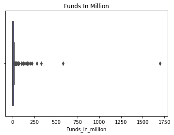

```python
#  Step 3.3 Plot box plot for funds in million
plt.title('Funds In Million')
sns.boxplot(CompanyX_EU1['Funds_in_million'],color='blue');
```

```python
# Step 3.4 Check the number of outliers greater than the upper
CompanyX_EU1['Funds_in_million'].describe()
```

```
count     446.000000
mean       17.241489
std        90.483710
min         0.005000
25%         0.745250
50%         2.200000
75%         9.475000
max      1700.000000
Name: Funds_in_million, dtype: float64
```

```python
#From the above data
q1 = 0.745250
q2 = 2.200000
q3 = 9.475000
#IQR = Q3 - Q1
iqr = q3-q1
print('IQR = ', iqr)
```

```
IQR =  8.72975
```

```python
# Finding upper and lower Fence
upperFence = q3 + (1.5 * iqr)
lowerFence = q1 - (1.5 * iqr)
print('Upper Fence :', upperFence)
print('Lower Fence :', lowerFence)
```

```
Upper Fence : 22.569625
Lower Fence : -12.349374999999998
```

```python
# 3.4 Number of outliers greater than the upper
CompanyX_EU1.Funds_in_million[CompanyX_EU1.Funds_in_million > upperFence].count()
```

```
60
```

```python
# 3.5 Check frequency of the OperatingState features classes ( later we can also check the
# updated frequency when we drop the outliers )
CompanyX_EU1.OperatingState.value_counts()
```

```
Operating    319
Acquired      66
Closed        57
Ipo            4
Name: OperatingState, dtype: int64
```

# To start solving problem 4 First remove the outliers

```python
CompanyX_EU1.drop(CompanyX_EU1[CompanyX_EU1.Funds_in_million > upperFence].index, inplace = True)
```

```python
#Recehcking the frequency distribution
CompanyX_EU1.OperatingState.value_counts()
```

```
Operating    275
Closed        56
Acquired      55
Name: OperatingState, dtype: int64
```

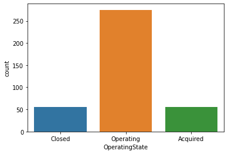

```python
#Recehcking the frequency distribution
sns.countplot(x=CompanyX_EU1.OperatingState)
```

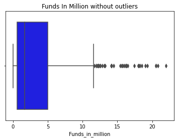

```python
#  Box plot for funds in million without outliers
plt.title('Funds In Million without outliers')
sns.boxplot(CompanyX_EU1['Funds_in_million'],color='blue');
```

### 4.1 Is there any significant difference between Funds raised by companies that are still operating vs companies that closed down?

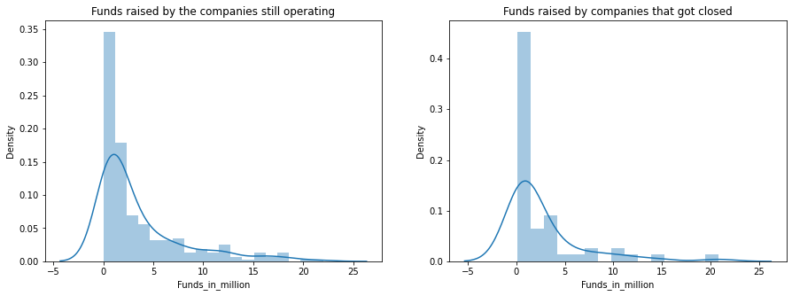

```python
fig, ax = plt.subplots(1, 2)

fig.set_figheight(5)
fig.set_figwidth(15)

sns.distplot(CompanyX_EU1.loc[CompanyX_EU1.OperatingState == 'Operating', 'Funds_in_million'], ax = ax[0])
sns.distplot(CompanyX_EU1.loc[CompanyX_EU1.OperatingState =='Closed', 'Funds_in_million'], ax = ax[1])

ax[0].set_title('Funds raised by the companies still operating')
ax[1].set_title('Funds raised by companies that got closed')
plt.show()
```

4.1

## 4.2 For the first test,

**Null hypothesis (Ho)** : There is no difference between the two means

**Alternate hypothesis (Ha)** : There is significant difference between the two means

```python
from statsmodels.stats.weightstats import ztest

sample1 = CompanyX_EU1.loc[CompanyX_EU1.OperatingState == 'Operating', 'Funds_in_million']
sample2 = CompanyX_EU1.loc[CompanyX_EU1.OperatingState =='Closed', 'Funds_in_million']

alpha = 0.05   # Let's consider a significance level of 5%

test_statistic, p_value = ztest(sample1, sample2)

if p_value <= alpha:
    print(f'Since the p-value, {round(p_value, 3)} < {alpha} (alpha) the difference is significant and we reject the Null hypothesis')
else:
    print(f'''\t Since the p-value, {round(p_value,3)} > {alpha} (alpha) the difference is not significant and,
    \t we fail to reject the Null hypothesis''')
```

```
	 Since the p-value, 0.192 > 0.05 (alpha) the difference is not significant and,
    	 we fail to reject the Null hypothesis
```

### - 4.3 From the tests above we found no evidence to state that the companies that have raised more money tend to suceed more or vice-versa

### 4.4 Make a copy of the original data frame

```python
CompanyX_EU2 = CompanyX_EU_orignal.copy(deep = True)
CompanyX_EU2.head()
```

|  | Startup | Product | Funding | Event | Result | OperatingState |
| --- | --- | --- | --- | --- | --- | --- |
| 0 | 2600Hz | 2600hz.com | NaN | Disrupt SF 2013 | Contestant | Operating |
| 1 | 3DLT | 3dlt.com | $630K | Disrupt NYC 2013 | Contestant | Closed |
| 2 | 3DPrinterOS | 3dprinteros.com | NaN | Disrupt SF 2016 | Contestant | Operating |
| 3 | 3Dprintler | 3dprintler.com | $1M | Disrupt NY 2016 | Audience choice | Operating |
| 4 | 42 Technologies | 42technologies.com | NaN | Disrupt NYC 2013 | Contestant | Operating |

#### 4.5 Check frequency distribution of Result variables.

```python
CompanyX_EU2.Result.value_counts()
```

```
Contestant         488
Finalist            84
Audience choice     41
Winner              26
Runner up           23
Name: Result, dtype: int64
```

#### There are 488 who remained contestants and the rest came out as something winner who are in categories ( Finalist, Audience choice, Winner, Runner up )

```python
winners = CompanyX_EU2.Result.value_counts()[1:].sum()
winners
```

```
174
```

```python
contestants = CompanyX_EU.Result.value_counts()['Contestant']
contestants
```

```
488
```

```python
contestants_operating = CompanyX_EU2.OperatingState[CompanyX_EU2.Result == 'Contestant'].value_counts().loc['Operating']
winners_operating = CompanyX_EU2.OperatingState[CompanyX_EU2.Result != 'Contestant'].value_counts().loc['Operating']
```

#### 4.6 Calculate percentage of winners that are still operating and percentage of contestants that are still operating

```python
winners_operating/winners, contestants_operating/contestants
```

```
(0.764367816091954, 0.680327868852459)
```

There is some difference between the proportion operational companies in the two categories, but let's see if the differnce is significant There are two ways we can check if the difference is significant Z-test for proportions Chi-square test We shall perform z-test in this case, however, do experiment with Chi-square test and observe if the p-value from both tests gives the same conclusion or not

### 4.7 Write your hypothesis comparing the proportion of companies that are operating between winners and contestants:

### Null hyputhesis (Ho): The proportion of companies that are operating is the same in both categories - winners and contestants

### Alternative hypothesis (Ha): The proportion of companies that are operating is significantly different from each other, among the two categories

```python
from statsmodels.stats.proportion import proportions_ztest,proportions_chisquare

test_statistic, p_value = proportions_ztest([contestants_operating, winners_operating], [contestants, winners])

if p_value <= alpha:
    print(f'Since the p-value, {round(p_value, 3)} < {alpha} (alpha) the difference is significant and we reject the Null hypothesis')
else:
    print(f'''\t Since the p-value, {round(p_value,3)} > {alpha} (alpha) the difference is not significant and,
    \t we fail to reject the Null hypothesis''')
```

```
Since the p-value, 0.037 < 0.05 (alpha) the difference is significant and we reject the Null hypothesis
```

#### P-value, 0.037 < 0.05 (alpha) the difference is significant and we reject the Null hypothesis that winners and contestants are operating in the same proportion

```python
ctab=pd.DataFrame([[contestants_operating, winners_operating],[contestants-contestants_operating, winners-winners_operating]])
ctab
```

|  | 0 | 1 |
| --- | --- | --- |
| 0 | 332 | 133 |
| 1 | 156 | 41 |

```python
c_stat,p_value,df,exp_freq=stats.chi2_contingency(ctab)
print('Chi-square statistic %3.5f P value %1.6f Degrees of freedom %d' %(c_stat, p_value,df))
```

```
Chi-square statistic 3.94118 P value 0.047118 Degrees of freedom 1
```

### 4.8 Test for significance and conclusion

#### P_value < 0.05, and chi2 > 1, so Reject the Null hypothesis¶

#### Winners are more operational than the contestants

# Conclusion:

- The amount of funds a company raises is not a significant factor in deciding if the company will remain operational or close down
- Winners in the tech-crunch battle have proven to remain operational more so, than the companies that came out only as contestants

### 4.9 Select only the Event that has ‘disrupt’ keyword from 2013 onwards.

```python
CompanyX_EU1[CompanyX_EU1.Event.apply(lambda x: 'Disrupt' in x and int(x[-4:]) > 2012)].Event.value_counts()
```

```
Disrupt NY 2015        21
Disrupt SF 2015        19
Disrupt NYC 2013       19
Disrupt SF 2014        19
Disrupt SF 2013        19
Disrupt SF 2016        17
Disrupt NY 2016        16
Disrupt NYC 2014       15
Disrupt London 2015    11
Disrupt London 2016    10
Disrupt EU 2014        10
Disrupt EU 2013         9
Name: Event, dtype: int64
```